# Exploratory data analysis of airquality

soubhagya Laxmi

19 December 2016

## Introduction

Fine particulate matter ($PM_{2.5}$) is an ambient air pollutant for which there is strong evidence that it is harmful to human health. In the United States, the Environmental Protection Agency (EPA) is tasked with setting national ambient air quality standards for fine PM and for tracking the emissions of this pollutant into the atmosphere. Approximatly every 3 years, the EPA releases its database on emissions of $PM_{2.5}$. This database is known as the National Emissions Inventory (NEI). You can read more information about the NEI at the [EPA National Emissions Inventory web site] (http://www.epa.gov/ttn/chief/eiinformation.html).

For each year and for each type of PM source, the NEI records how many tons of $PM_{2.5}$ were emitted from that source over the course of the entire year. The data that you will use for this assignment are for 1999, 2002, 2005, and 2008.

## Data

The data for this assignment are available from the course web site as a single zip file:

- [Data for Peer Assessment] (https://d396qusza40orc.cloudfront.net/exdata%2Fdata%2FNEI_data.zip) [29Mb]

The zip file contains two files:

$PM_{2.5}$ Emissions Data (`summarySCC_PM25.rds`): This file contains a data frame with all of the PM2.5 emissions data for 1999, 2002, 2005, and 2008. For each year, the table contains number of **tons** of $PM_{2.5}$ emitted from a specific type of source for the entire year. Here are the first few rows.

```
##     fips      SCC Pollutant Emissions  type year
## 4  09001 10100401  PM25-PRI    15.714 POINT 1999
## 8  09001 10100404  PM25-PRI   234.178 POINT 1999
## 12 09001 10100501  PM25-PRI     0.128 POINT 1999
## 16 09001 10200401  PM25-PRI     2.036 POINT 1999
## 20 09001 10200504  PM25-PRI     0.388 POINT 1999
## 24 09001 10200602  PM25-PRI     1.490 POINT 1999
```

- `fips`: A five-digit number (represented as a string) indicating the U.S. county
- `SCC`: The name of the source as indicated by a digit string (see source code classification table)
- `Pollutant`: A string indicating the pollutant
- `Emissions`: Amount of PM2.5 emitted, in tons
- `type`: The type of source (point, non-point, on-road, or non-road)
- `year`: The year of emissions recorded

Source Classification Code Table (`Source_Classification_Code.rds`): This table provides a mapping from the SCC digit strings int he Emissions table to the actual name of the $PM_{2.5}$ source. The sources are categorized in a few different ways from more general to more specific and you may choose to explore whatever categories you think are most useful. For example, source “10100101” is known as “Ext Comb /Electric Gen /Anthracite Coal /Pulverized Coal”.

# Loading provided datasets - loading from local machine

```r
library(ggplot2)
NEI <- readRDS("E:/shubbi study/Coursera project data set/exdata_data_NEI_data/summarySCC_PM25.rds")
SCC <- readRDS("E:/shubbi study/Coursera project data set/exdata_data_NEI_data/Source_Classification_Code.rds")
```

# Sampling

```r
NEI_sampling <- NEI[sample(nrow(NEI), size=2000, replace=F), ]
```

# Aggregate

```r
Emissions <- aggregate(NEI[, 'Emissions'], by=list(NEI$year), FUN=sum)

Emissions$PM <- round(Emissions[,2]/1000,2)
```

# Generate the plot for years 1999, 2002, 2005, and 2008.

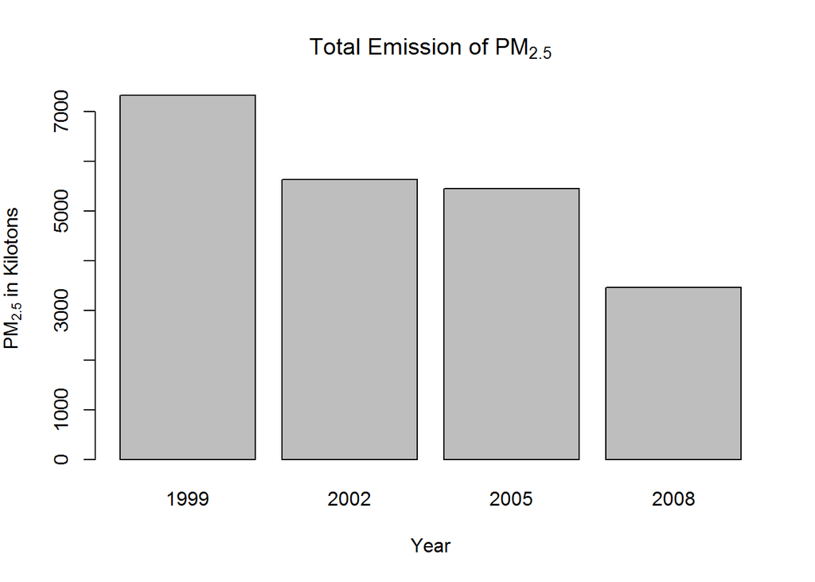

```r
barplot(Emissions$PM, names.arg=Emissions$Group.1,

        main=expression('Total Emission of PM'[2.5]),

        xlab='Year', ylab=expression(paste('PM', ''[2.5], ' in Kilotons')))
```

It shows total emissions from PM2.5 decreased in the United States from 1999 to 2008

# subset for baltimore city Maryland (fips == “24510”)

```r
MD <- subset(NEI, fips=='24510')
head(MD)
```

```
        fips      SCC Pollutant Emissions  type year
114288 24510 10100601  PM25-PRI     6.532 POINT 1999
114296 24510 10200601  PM25-PRI    78.880 POINT 1999
114300 24510 10200602  PM25-PRI     0.920 POINT 1999
114308 24510 30100699  PM25-PRI    10.376 POINT 1999
114325 24510 30183001  PM25-PRI    10.859 POINT 1999
114329 24510 30201599  PM25-PRI    83.025 POINT 1999
```

# Generate the plot for Baltimore City, Maryland (fips == “24510”)

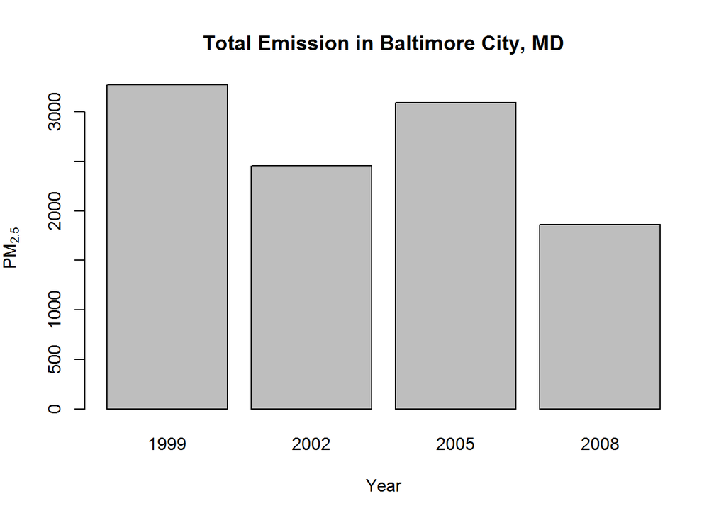

```r
barplot(tapply(X=MD$Emissions, INDEX=MD$year, FUN=sum),

        main='Total Emission in Baltimore City, MD',

        xlab='Year', ylab=expression('PM'[2.5]))
```

# Baltimore City, Maryland == fips

```r
MD$year <- factor(MD$year, levels=c('1999', '2002', '2005', '2008'))
```

# Generate plot for emission per type of sources

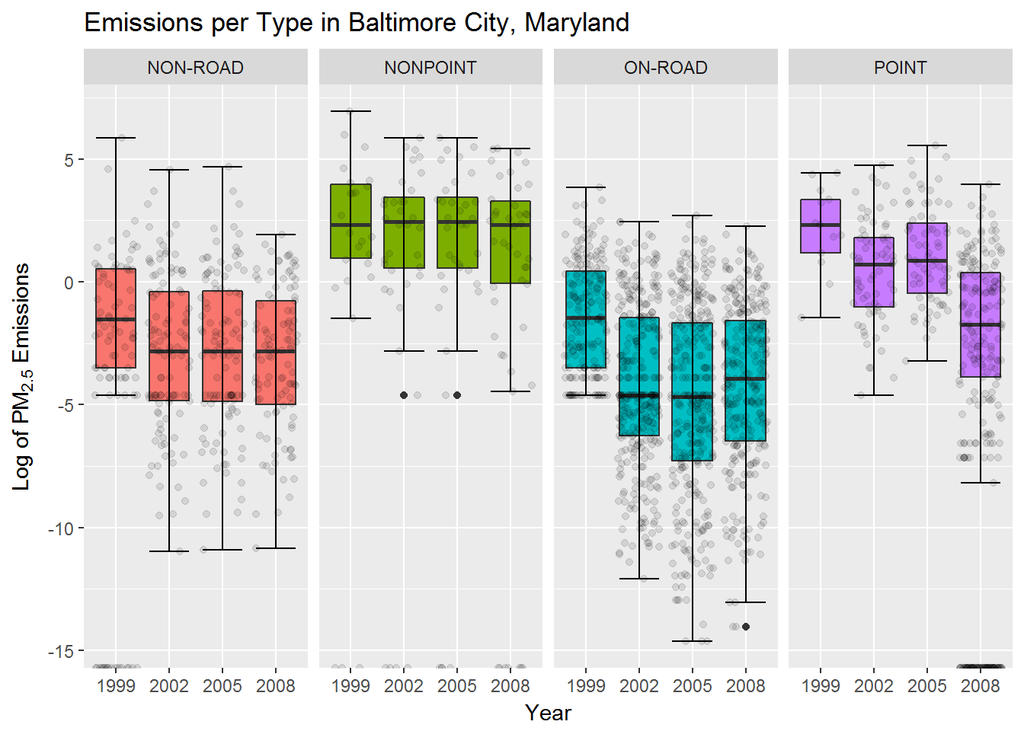

```r
p <- ggplot(data=MD, aes(x=year, y=log(Emissions)))+
  facet_grid(. ~ type) +
  guides(fill=F) +
  geom_boxplot(aes(fill=type)) +
  stat_boxplot(geom ='errorbar') +
  ylab(expression(paste('Log', ' of PM'[2.5], ' Emissions'))) +
  xlab('Year') +ggtitle('Emissions per Type in Baltimore City, Maryland') +
  geom_jitter(alpha=0.10)
print(p)
```

# Coal combustion related sources

```r
SCC.coal = SCC[grepl("coal", SCC$Short.Name, ignore.case=TRUE),]
```

# Merge two data sets

```r
merge <- merge(x=NEI, y=SCC.coal, by='SCC')
merge.sum <- aggregate(merge[, 'Emissions'], by=list(merge$year), sum)
colnames(merge.sum) <- c('Year', 'Emissions')
```

# Plot showing emissions from coal combustion-related sources changed from 1999-2008

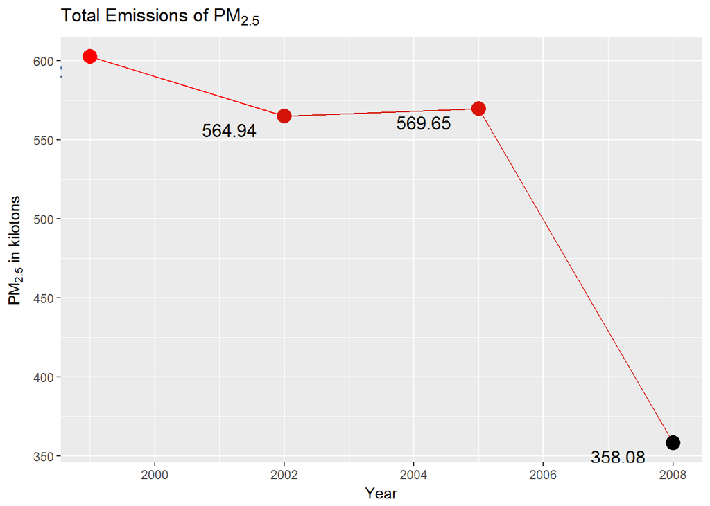

```r
 plot2 <- ggplot(data=merge.sum, aes(x=Year, y=Emissions/1000)) +
          geom_line(aes(group=1, col=Emissions)) +
          geom_point(aes(size=2, col=Emissions)) +
          ggtitle(expression('Total Emissions of PM'[2.5])) +
          ylab(expression(paste('PM', ''[2.5], ' in kilotons'))) +
          geom_text(aes(label=round(Emissions/1000,digits=2), size=2, hjust=1.5, vjust=1.5)) +
          theme(legend.position='none') +
          scale_colour_gradient(low='black', high='red')
print(plot2)
```